# Ma_ALY6000Project6

Task 7 **Generate pie chart/bar plot from Task 6’s result.**

```r
group_by_Market = Task6M6dataset %>%
  group_by(Market) %>%
  summarise(Total_sales = sum(Product_Price * Quantity)) %>%
  kable(col.names = c("Market", "Total Sales"), align = "cc") %>%
  kable_styling(bootstrap_options = c("striped", "hover", "condensed", "responsive"))

group_by_Segment = Task6M6dataset %>%
  group_by(Segment) %>%
  summarise(Total_sales = sum(Product_Price * Quantity)) %>%
  kable(col.names = c("Segment", "Total Sales"), align = "cc") %>%
  kable_styling(bootstrap_options = c("striped", "hover", "condensed", "responsive"))

group_by_Department = Task6M6dataset %>%
  group_by(Department) %>%
  summarise(Total_sales = sum(Product_Price * Quantity)) %>%
  kable(col.names = c("Department", "Total Sales"), align = "cc") %>%
  kable_styling(bootstrap_options = c("striped", "hover", "condensed", "responsive"))
```

I summarized 3 table for total sales amount group by different attributes including:

A table grouped by different market, with highest total sales in Asia Pacific (24704625).

| Market | Total Sales |
| --- | --- |
| Africa | 5127296 |
| Asia Pacific | 24704625 |
| Europe | 24627127 |
| LATAM | 14005415 |
| USCA | 9533931 |

A table grouped by different segment.with highest total sales in Consumer (41640653).

| Segment | Total Sales |
| --- | --- |
| Consumer | 41640653 |
| Corporate | 23377596 |
| Home Office | 12980145 |

A table grouped by different department.with highest total sales in Office Supplies (43461505).

| Department | Total Sales |
| --- | --- |
| Furniture | 6772320 |
| Office Supplies | 43461505 |
| Technology | 27764569 |

Task 8 **Observe the relationship between product price/quantity/shipping cost/region.**

```r
options(dplyr.summarise.inform = FALSE)
summary_by_category = M6dataset %>%
  group_by(Region, Market, Department) %>%
  summarise(Price_mean = mean(Product_Price),
            Quantity_mean = mean(Quantity),
            Shipping_cost_mean = mean(Shipping_Cost_Each))

# Create scatterplots of product price, quantity, and shipping cost
scatterplot_matrix = ggplot(M6dataset, aes(x = Product_Price, y = Quantity)) +
  geom_point() +
  labs(x = "Product Price", y = "Quantity")

scatterplot_matrix = scatterplot_matrix + ggtitle("Scatterplot Matrix") +
  geom_point(aes(color = Shipping_Cost_Each), size = 2)

# Create boxplots of product price, quantity, and shipping cost by country
boxplot_price_by_Region = ggplot(M6dataset, aes(x = Region, y = Product_Price)) +
  geom_boxplot() +
  ggtitle("Product Price by Region") +
  theme(axis.text.x = element_text(angle = 90, vjust = 0.5, hjust=1)) +
  coord_cartesian(ylim = c(0, 1500))

boxplot_quantity_by_Region = ggplot(M6dataset, aes(x = Region, y = Quantity)) +
  geom_boxplot() +
  ggtitle("Quantity by Region") +
  theme(axis.text.x = element_text(angle = 90, vjust = 0.5, hjust=1))

boxplot_shipping_cost_by_Region = ggplot(M6dataset, aes(x = Region, y = Shipping_Cost_Each)) +
  geom_boxplot() +
  ggtitle("Shipping Cost by Region") +
  theme(axis.text.x = element_text(angle = 90, vjust = 0.5, hjust=1))



# Print the results
#cat("Summary statistics by country, market, and company department:\n")
#kable(summary_by_category, format = "markdown")
```

```r
cat("Scatterplot matrix of product price, quantity, and shipping cost:\n")
```

```
## Scatterplot matrix of product price, quantity, and shipping cost:
```

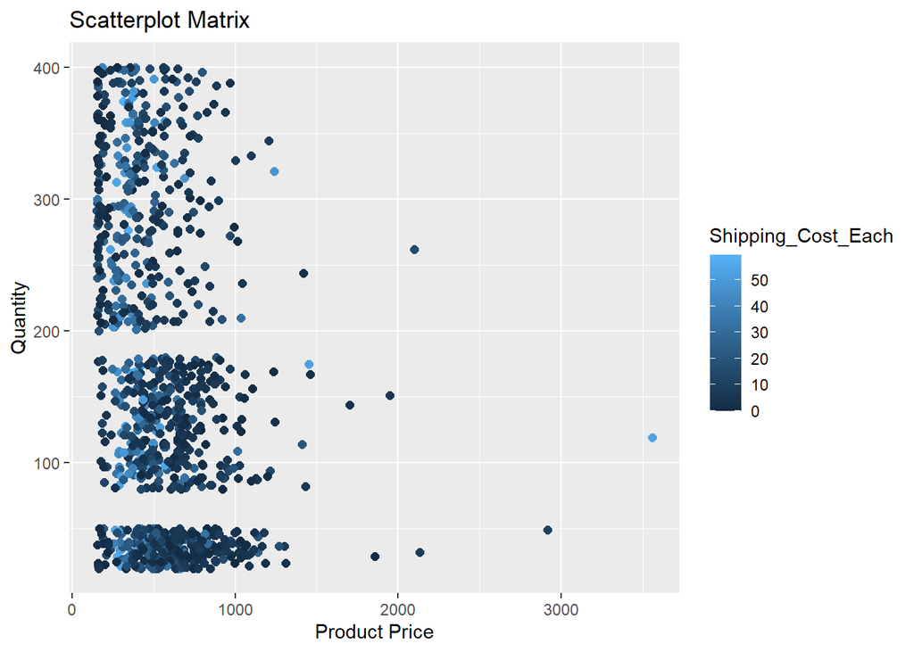

```r
print(scatterplot_matrix)
```

At first, from the scatter plot above, we can see the high product price doesn’t mean shipping cost is also very high in higher price area(x>500), which means they may not be a strong positive correlation between these two variables, at least not in full interval.It is possible that there may be other factors at play that influence shipping cost, such as the size or weight of the product, the shipping method or distance, or the location of the shipping destination. It may be helpful to conduct further analysis or statistical tests to determine whether there is a significant relationship between product price and shipping cost, and what other factors may be impacting shipping cost. So I think it could related to price/quantity/region.

```r
cat("Boxplots of product price, quantity, and shipping cost by country:\n")
```

```
## Boxplots of product price, quantity, and shipping cost by country:
```

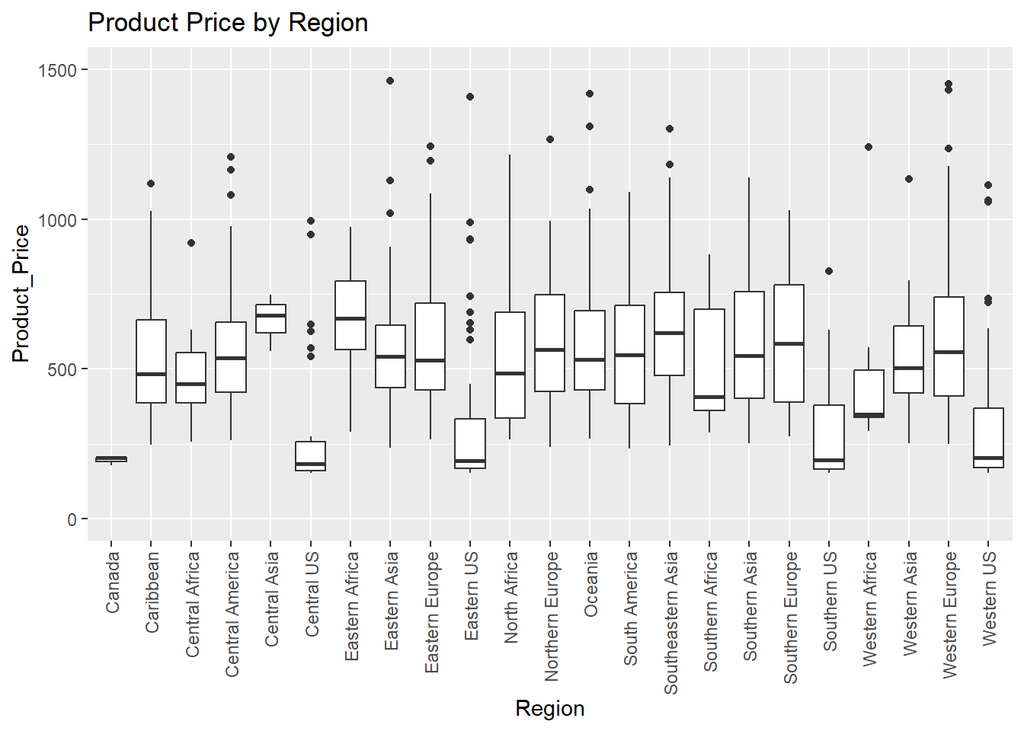

```r
print(boxplot_price_by_Region)
```

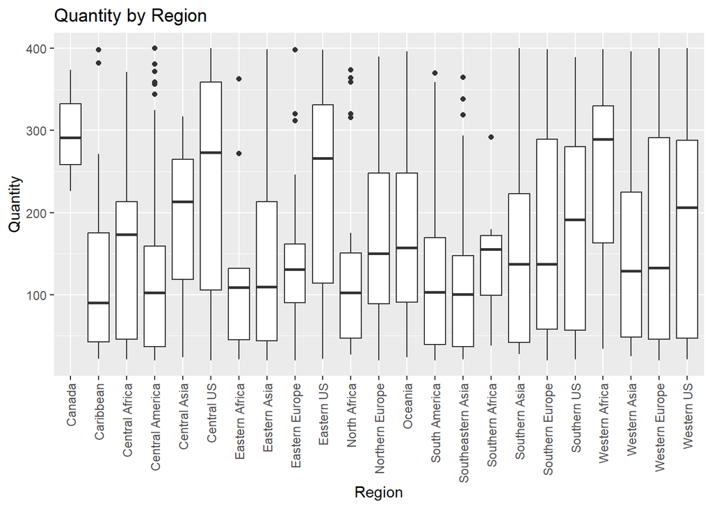

```r
print(boxplot_quantity_by_Region)
```

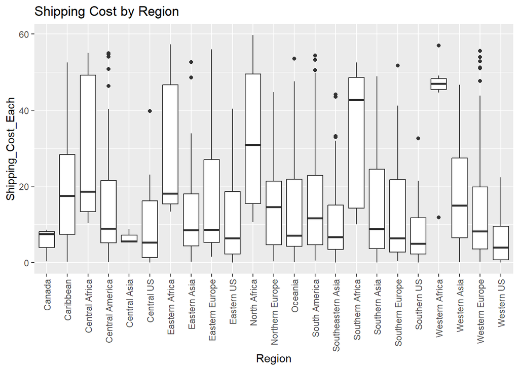

```r
print(boxplot_shipping_cost_by_Region)
```

Final sections

In this report, we find out the item shipping cost have relation ship to the region, and it’s possible because of the local transport situation, as shipping cost is one of the major point of the over cost. It’s a good idea to investigate the shipping price more carefully in local range to make better approximate to the real cost of the busyness.

Bibliography

Kotler, P., & Keller, K. L. (2016). Marketing Management (15th ed.). Pearson.

Group by one or more variables - group_by. - group_by • dplyr. (n.d.). Retrieved February 18, 2023, from https://dplyr.tidyverse.org/reference/group_by.html

Draw Boxplot with means in R (2 examples): Add mean values to graph. Statistics Globe. (2022, March 18). Retrieved February 18, 2023, from https://statisticsglobe.com/draw-boxplot-with-means-in-r

Yihui Xie, C. D. (2022, November 7). R markdown cookbook. 10.1 The function knitr::kable(). Retrieved February 18, 2023, from https://bookdown.org/yihui/rmarkdown-cookbook/kable.html

Acknowledgments

Two person helps me most here is my classmate Sai Sharat Paila who gives me a lot of good advices on project 4 presentations. Also the professor Dee make prefect project that guide us learn how to write a report in scratch.

Conclusions

This project is about analyse the business data sets. I got no business background, and I also don’t watch related news, and that cause me have minimum situation awareness. I had a hard time on finding possible relationship between different data. That could cause my report less useful than other students be cause what could companies want from this report. From this report, I have tried to used ggplot library in the last part, which make the fist plot looks amazing and great for visualization data. If I’m working for a company, I would tell them the shipment part is very important, and it’s a good idear to use neural network to do more research on it. I do the coding part first when complete Task 1 to 7, and do them together when doing Task 8, which make me feels more efficient overall.

Appendix

An R Markdown file has been attached to this report. The name of the file is “Ma_ALY6000Project6.Rmd”